# MPRAsnakeflow experiment QC report

**Good Spearman correlation across replicates!**

The data has a good Spearman correlations across replicates using a barcode threshold per oligo of 10! Spearman correlation of DNA is 1.00, RNA is 0.98 and DNA/RNA ratio is 0.96.

# Overall quality metrics

**Table explanation**

- **median rna read count:** Median of RNA read count for oligos that passed filtering to determine sufficient coverage in terms of read count. Value is the median of all replicates.
- **median barcodes passing filtering:** Median number of barcodes across tested sequences that passed filtering to determine if there was sufficient barcode to oligo coverage. Value is the median of all replicates.
- **pearson correlation:** The correlation of log2 RNA/DNA ratios across tested sequences as a measure of replicable activity signal. Value is the median of replicate comparisons using only oligos with >= 10 barcodes.
- **fraction oligos passing:** Fraction of tested sequences that passed filtering of the mappable sequences to determine if the designed library was sufficiently recovered. Value is the median of all replicates and using only oligos with >= 10 barcodes.

| median barcodes passing filtering | median rna read count | pearson correlation | fraction oligos passing |
| --- | --- | --- | --- |
| 176 | 12219 | 0.97 | 0.96 |

# DNA over RNA counts

Plotting normalized counts of DNA vs RNA (median across replicates). Only oligos within all replicates are shown. We should see a variation within the RNA count data (along the y axis). If count data between RNA and DNA is highly correlated (e.g. follows the identity line) there is no variation between designed oligos. This is an indication that RNA is inflated with DNA and the DNA digestion before creating cDNA did not work as expected.

**Threshold 10**

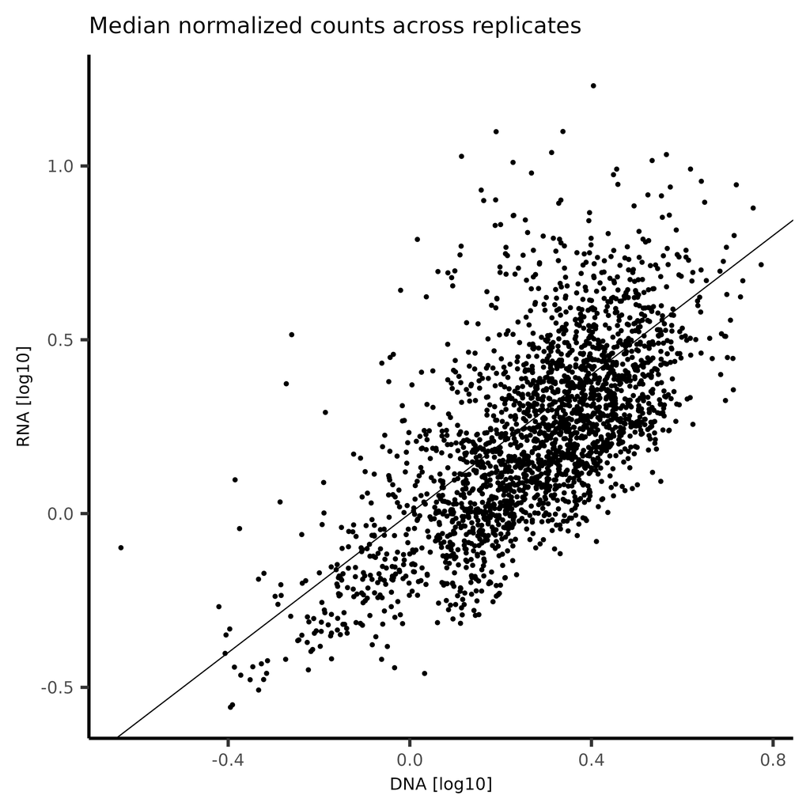

**All**

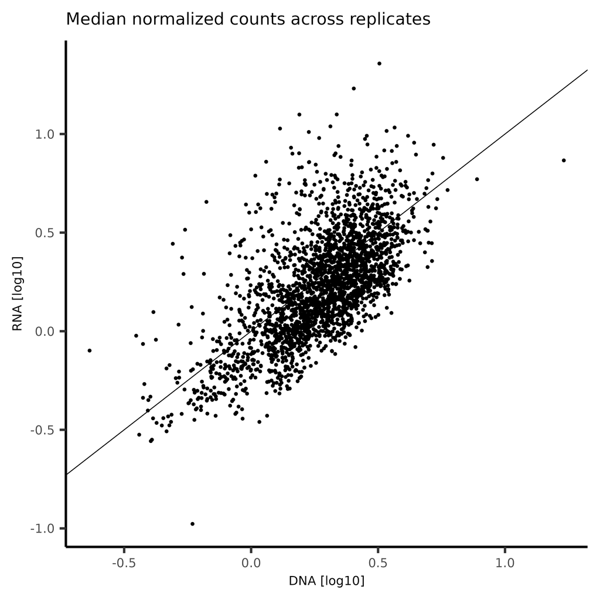

# Oligo correlation

Oligo correlation plots of DNA, RNA and DNA/RNA ratios across replicates. First tab shows plots using (in average) 2302 oligos with a minimum number of 10 barcodes. Second tab shows all 2391 oligos that have assigned barcodes.

**Threshold 10**

| Condition | A | B | #Oligos A | #Oligos B | #Oligos Joined | DNA spearman | RNA spearman | Ratio spearman | DNA log2 pearson | RNA log2 pearson | Ratio log2 pearson |
| --- | --- | --- | --- | --- | --- | --- | --- | --- | --- | --- | --- |
| HEPG2 | 1 | 2 | 2303 | 2302 | 2302 | 1.00 | 0.98 | 0.96 | 1.00 | 0.98 | 0.96 |
| HEPG2 | 1 | 3 | 2303 | 2303 | 2303 | 1.00 | 0.98 | 0.97 | 1.00 | 0.98 | 0.97 |
| HEPG2 | 2 | 3 | 2302 | 2303 | 2302 | 1.00 | 1.00 | 0.99 | 1.00 | 1.00 | 0.99 |

**All**

| Condition | A | B | #Oligos A | #Oligos B | #Oligos Joined | DNA spearman | RNA spearman | Ratio spearman | DNA log2 pearson | RNA log2 pearson | Ratio log2 pearson |
| --- | --- | --- | --- | --- | --- | --- | --- | --- | --- | --- | --- |
| HEPG2 | 1 | 2 | 2391 | 2391 | 2391 | 0.99 | 0.98 | 0.96 | 0.98 | 0.98 | 0.95 |
| HEPG2 | 1 | 3 | 2391 | 2391 | 2391 | 0.99 | 0.98 | 0.97 | 0.99 | 0.98 | 0.97 |
| HEPG2 | 2 | 3 | 2391 | 2391 | 2391 | 0.99 | 0.99 | 0.99 | 0.99 | 0.99 | 0.98 |

**Threshold 10**

**DNA**

[figure not shown]

**RNA**

[figure not shown]

**Ratio**

[figure not shown]

**All**

**DNA**

[figure not shown]

**RNA**

[figure not shown]

**Ratio**

[figure not shown]

# Experiment statistic

The total number of oligos in this experiment is 2398 (defined by the assignment) with 938503 associated barcodes.

In average across replicates we see 2391 from 458793 average barcodes in the count data and around 377459 barcodes where not in the assignment.

**DNA/RNA merged**

| condition | replicate | oligos dna/rna | matched barcodes | unknown barcodes dna/rna | % matched barcodes | total dna counts | total rna counts | avg dna counts per bc | avg rna counts per bc | barcode outlier removed | avg dna/rna barcodes per oligo |
| --- | --- | --- | --- | --- | --- | --- | --- | --- | --- | --- | --- |
| HEPG2 | 1 | 2391 | 458257 | 376434 | 54.90 | 21004482 | 55170694 | 25.16 | 66.10 | 0 | 191.66 |
| HEPG2 | 2 | 2391 | 455230 | 295651 | 60.63 | 20013568 | 36062019 | 26.65 | 48.03 | 0 | 190.39 |
| HEPG2 | 3 | 2391 | 462892 | 460293 | 50.14 | 29614442 | 55689490 | 32.08 | 60.32 | 0 | 193.60 |

**DNA/RNA individual**

| Experiment | Barcodes | Counts | Average counts | Assigned barcodes | Assigned counts | Average assigned counts | Fraction assigned barcodes | Fraction assigned counts |
| --- | --- | --- | --- | --- | --- | --- | --- | --- |
| HEPG2_1_DNA | 1712841 | 21963536 | 12.82 | 469723 | 17029745 | 36.25 | 0.27 | 0.78 |
| HEPG2_2_DNA | 1644087 | 20988769 | 12.77 | 467676 | 16298530 | 34.85 | 0.28 | 0.78 |
| HEPG2_3_DNA | 2111800 | 30931132 | 14.65 | 477894 | 24014893 | 50.25 | 0.23 | 0.78 |
| HEPG2_1_RNA | 2778617 | 57511450 | 20.70 | 487093 | 43587160 | 89.48 | 0.18 | 0.76 |
| HEPG2_2_RNA | 2198782 | 37761809 | 17.17 | 482239 | 28543719 | 59.19 | 0.22 | 0.76 |
| HEPG2_3_RNA | 2777070 | 57875481 | 20.84 | 487877 | 43863866 | 89.91 | 0.18 | 0.76 |

# Histograms barcodes per oligo, counts per barcode

Histogramm of number of barcodes per oligo and the number of counts per barcode devidied by DNA and RNA. Median is red, mean is blue.

**Number of barcodes per oligo**

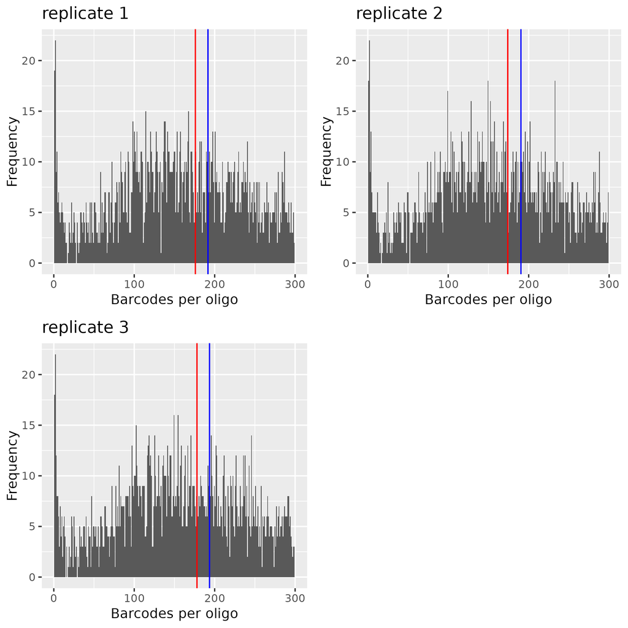

**Number of counts per DNA barcode**

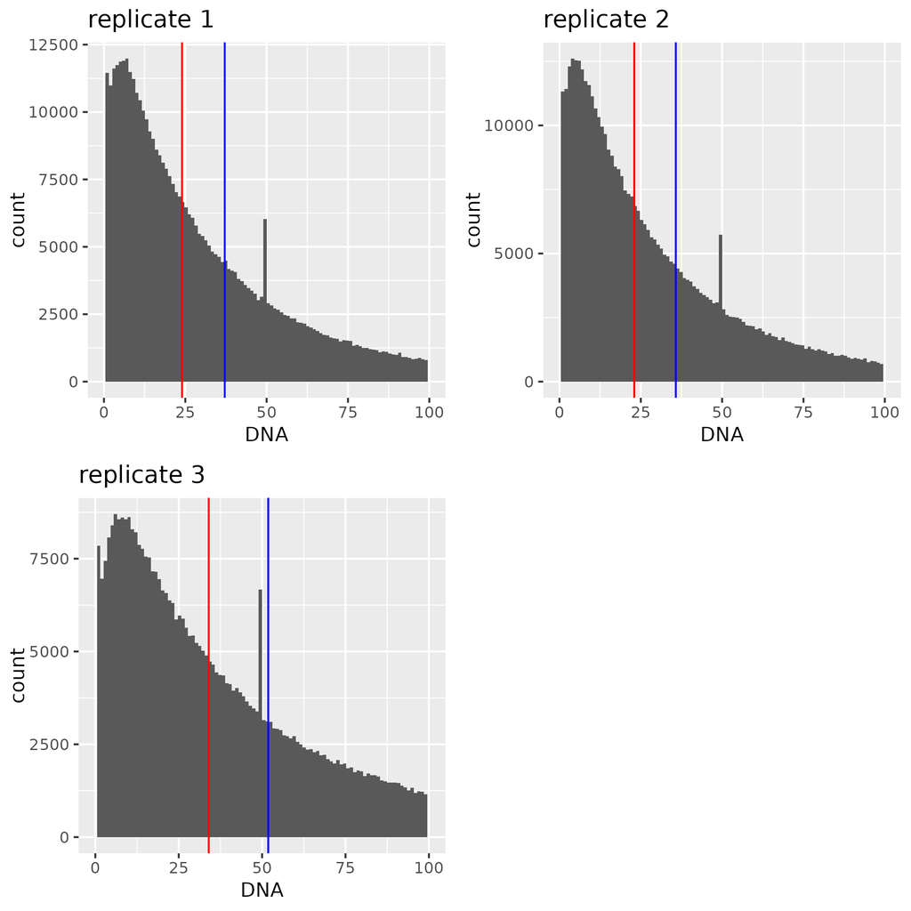

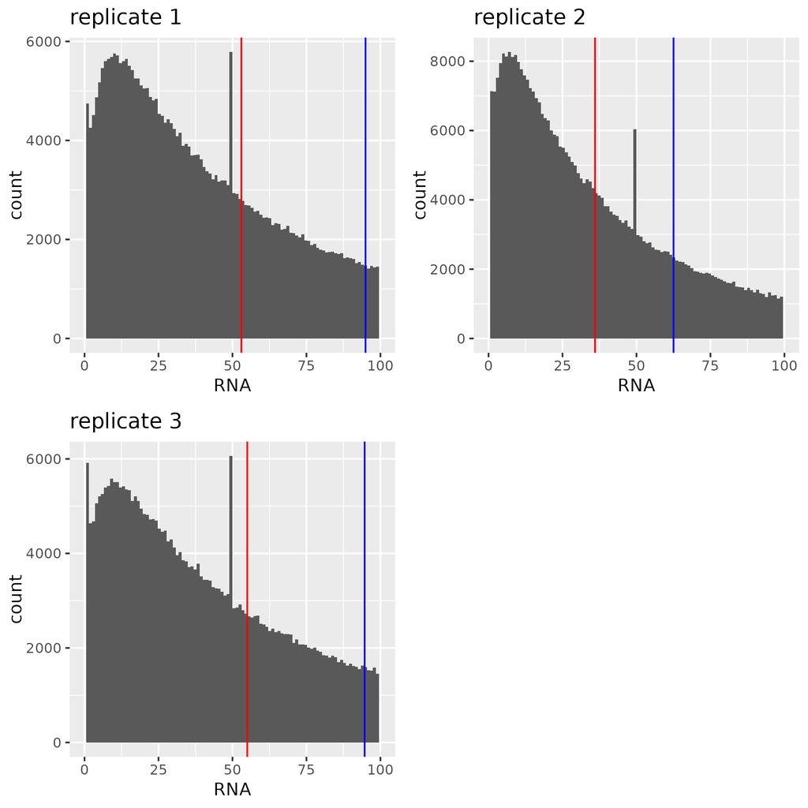

# Activity

Violin and box plots of the log2 fold change of all oligos by the assay. Grouped by labels if set, otherwise `NA`. First tab shows plots using (in average) 2302 oligos with a minimum number of 10 barcodes. Second tab shows all 2391 oligos that have assigned barcodes.

**Threshold 10**

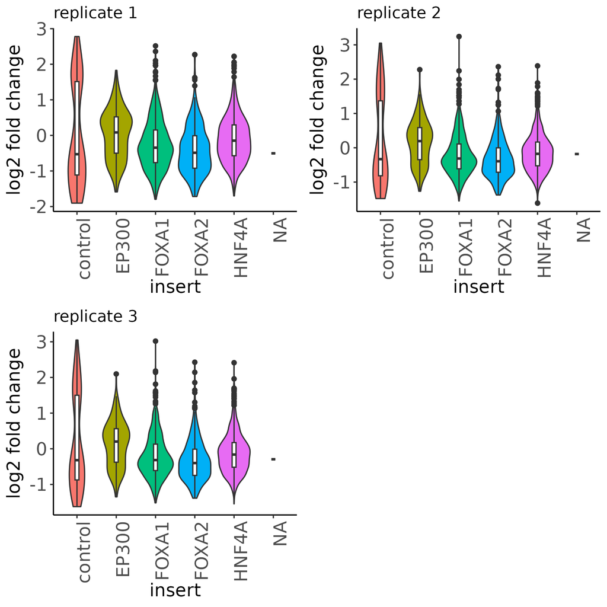

**All**

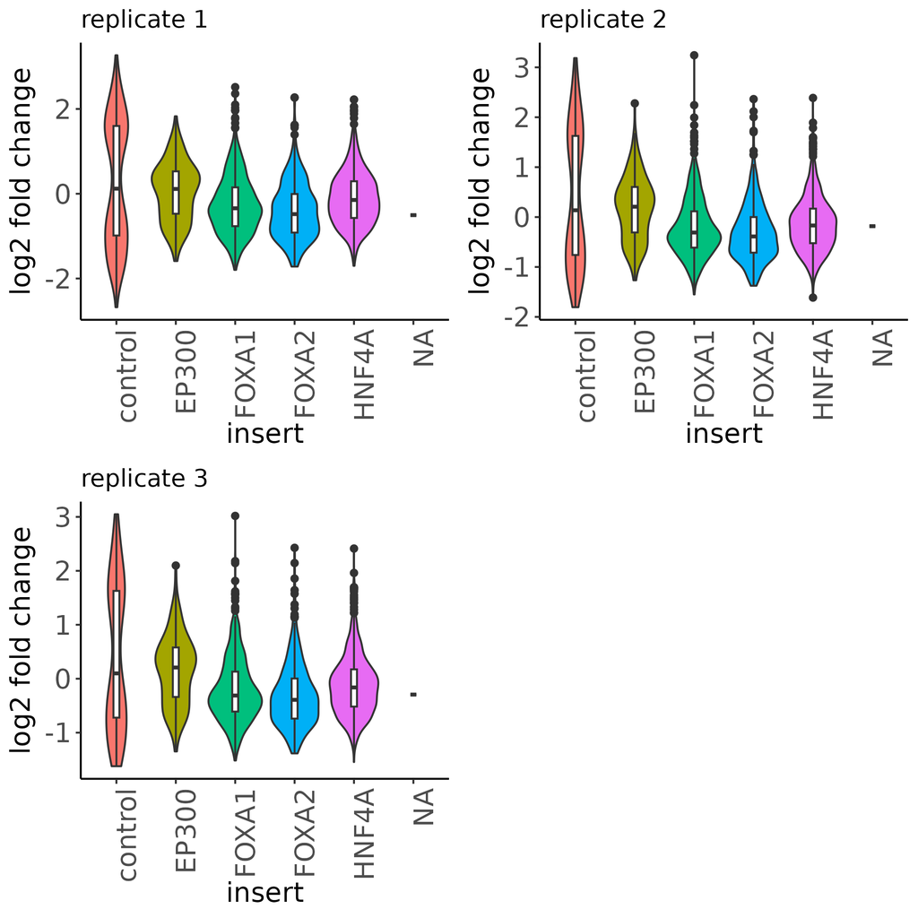